# Propositions as Types

A Beginner’s Approach to Program Synthesis

Dhruv Nevatia

ETH Zürich

2026-07-19

## Hi, I am Dhruv!

PhD student in the **Information Security** group at ETH Zürich, and a **CYD Fellow**.

I find ways for machines to *prove* their own configurations *correct*.

Lately these have been “DNS configurations”, the internet’s least glamorous piece of critical infrastructure.

And hence, a low-hanging fruit. Come talk to me if you are curious.

I also co-organize **Papers We Love Zürich**, ensuring every talk has a speaker.

rest of me

[figure not shown]

## That’s it from me!

## Let’s Be Reasonable…

Two thousand years, one stubborn idea:

*that reasoning could be reduced to* **calculation.**

## Rules of Reason

Antiquity → the Schoolmen :

[figure not shown]

Aristotle ·

[figure not shown]

Chrysippus ·

[figure not shown]

Ockham

Logic begins as **rules** for valid argument — Aristotle’s syllogism, sharpened by the medieval scholastics.

## “Let Us Calculate”

c. 1700 :

[figure not shown]

Leibniz

Leibniz dreams of a *calculus ratiocinator*: settle any dispute by **computation**. *“Calculemus.”*

## Logic Becomes Algebra

[figure not shown]

Boole ·

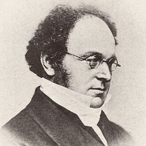

De Morgan ·

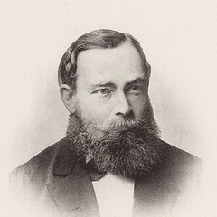

Frege ·

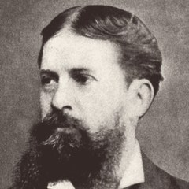

Peirce ·

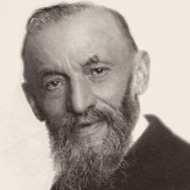

Peano

**Formal** logic is born — reasoning reduced to *symbols and laws*, the way algebra tamed arithmetic.

## Principia Mathematica

1910 :

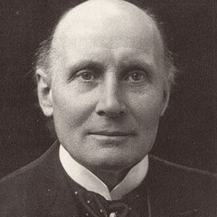

Whitehead ·

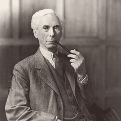

Russell

Formal logic can express a large part of *mathematics itself* — three volumes to reach $1 + 1 = 2$.

## Foundations

1920s · Göttingen :

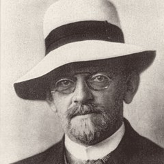

Hilbert

Hilbert’s program: put all of mathematics on a *firm, mechanical* footing. **Can a procedure decide every truth?**

## The Dream Breaks

To prove that **no procedure** could decide every truth, they first had to say exactly what a *procedure* is.

## The Limits of Proof

1931 · Vienna :

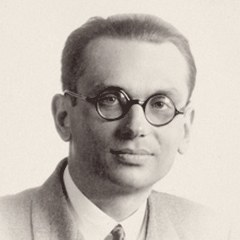

Gödel

Some true statements have **no proof**. No consistent system can capture all of arithmetic — Hilbert’s dream of completeness is over.

## A Calculus of Functions

1936 · Princeton :

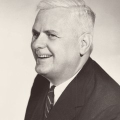

Church

Church builds the **$\lambda$-calculus** — and proves no procedure can decide every statement. *(Remember the $\lambda$-calculus. It comes back.)*

## The Machine

1936 · Cambridge :

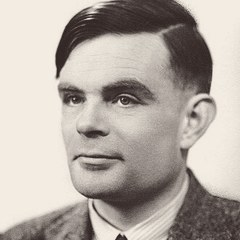

Turing

Turing imagines a simple **machine** — and the halting problem shows, once more, that no procedure decides every truth.

## One Notion of Computation

Three formalisms — recursive functions, the $\lambda$-calculus, Turing machines — turn out to be **exactly equivalent.**

So Hilbert had his answer: **No.**

But Church’s $\lambda$-calculus had quietly become something else —

a *programming language.*

## What’s Your Ideal Type?

Logic took two thousand years to become mechanical.

*Types* took about one century — and ended up **everywhere.**

## A Theory of Types

1908 :

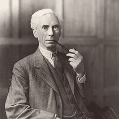

Russell

To escape his own paradox, Russell stratifies everything into **types** — a discipline that simply forbids you from writing nonsense.

## Types for Computation

1940 · Princeton :

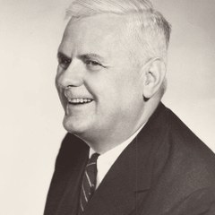

Church

Church gives every term (or **program**) of the $\lambda$-calculus a type — the **simply-typed $\lambda$-calculus**, the exact system in this talk.

## Types as a Foundation

1972 · Stockholm :

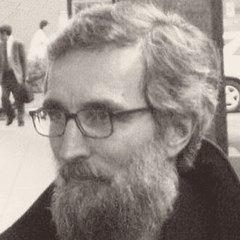

Martin-Löf

Martin-Löf makes types rich enough to found mathematics: a type can **depend on a value**, so a type becomes a full *specification*.

## Types the Machine Infers

1978 · Edinburgh :

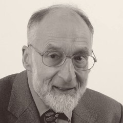

Milner

Milner’s **ML** infers your types for you and reuses code across them. His slogan: *“well-typed programs cannot go wrong.”*

## Types Everywhere

Today

Haskell, OCaml, Rust, TypeScript — and proof assistants **Coq, Agda, Lean.** Every one of them is built on the type discipline above.

## The Big Idea

Two worlds turn out to be the *same* world:

Logic

Computation

propositions

⟷

types

proofs

⟷

programs

proof simplification

⟷

program evaluation

This is the **Curry–Howard correspondence** — one of the most fruitful “coincidences” in theoretical computer science.

## Some Formalism

Two systems, written almost identically:

### Intuitionistic Logic

$$\Gamma \vdash A$$

“from $\Gamma$, we can **prove** $A$”

A proof is *evidence* for $A$.

### Simply-Typed $\lambda$-Calculus

$$\Gamma \vdash e : A$$

“$e$ has **type** $A$ in context $\Gamma$”

A term is a *program*; its type, its spec.

The only difference is the term $e$. **Erase it and the logic reappears.**

## Connective by Connective

Read across: each way of *stating* something is a way of *building* it.

Proposition

Type

Program

\(A \to B\)

\(A \to B\)

\(\lambda x.\, e\)

\(A \land B\)

\(A \times B\)

\((a,\ b)\)

\(A \lor B\)

\(A + B\)

\(\mathsf{inL}\,a \ \mid\ \mathsf{inR}\,b\)

Implication is a **function**, “and” is a **pair**, “or” is a **tagged choice**.

## One Rule, Three Ways

The **rules of inference** also line up. For instance, take the introduction of implication:

Logic
$$\dfrac{\Gamma,\ A \;\vdash\; B}{\Gamma \;\vdash\; A \to B}\ \ {\scriptsize(\to I)}$$

Types
$$\dfrac{\Gamma,\ x : A \;\vdash\; e : B}{\Gamma \;\vdash\; \lambda x.e \;:\; A \to B}\ \ {\scriptsize(\to I)}$$

Program $\lambda x.\, e$ is the program `\x -> e` — take an `x : A`, return `e : B`.

**Erase the terms and Types is Logic.** The proof you found *is* the program.

## Another Rule, Three Ways

Introduction *builds* a function. Elimination *uses* one — **modus ponens:**

Logic
$$\dfrac{\Gamma \;\vdash\; A \to B \qquad \Gamma \;\vdash\; A}{\Gamma \;\vdash\; B}\ \ {\scriptsize(\to E)}$$

Types
$$\dfrac{\Gamma \;\vdash\; f : A \to B \qquad \Gamma \;\vdash\; a : A}{\Gamma \;\vdash\; f\,a \;:\; B}\ \ {\scriptsize(\to E)}$$

Program $f\,a$ is the program `f a` — apply the function to its argument.

Introduction was $\lambda$; elimination is application. Put one *next to* the other and you get a **detour** — which is exactly what runs next.

## Simplify a Proof = Run a Program

A **detour**: *introduce* a connective, then *immediately eliminate* it. As a proof tree, a $\to\!I$ feeds straight into a $\to\!E$:

$$\dfrac{
\dfrac{\begin{array}{c}[\,x:A\,]\\[2pt] \vdots\\[2pt] e:B\end{array}}{\lambda x.e \;:\; A\to B}\,{\scriptsize(\to I)}
\qquad a:A
}{(\lambda x.e)\,a \;:\; B}\,{\scriptsize(\to E)}
\qquad\Longrightarrow\qquad
\begin{array}{c} a:A\\[2pt] \vdots\\[2pt] e[a/x]\;:\;B \end{array}$$

The detour vanishes — plug the proof of $a:A$ into every $[\,x:A\,]$ leaf. That deletion **is** the reduction $(\lambda x.e)\,a \rightsquigarrow e[a/x]$.

$\land$ and $\lor$ carry detours of the very same shape: a `pair` meeting `fst`, an `inL` meeting a `case`.

## The Same Detour: $\land$

Keep the left proof, discard the right — exactly $\mathsf{fst}\,(a,\,b) \rightsquigarrow a$.

## The Same Detour: $\lor$

Tag a value with `inL`, then immediately branch on it with `case`. A $\lor I$ feeds straight into a $\lor E$:

$$\dfrac{
\dfrac{a:A}{\mathsf{inL}\,a : A\lor B}\,{\scriptsize(\lor I_l)}
\quad
\begin{array}{c}[\,x:A\,]\\[2pt] \vdots\\[2pt] e:C\end{array}
\quad
\begin{array}{c}[\,y:B\,]\\[2pt] \vdots\\[2pt] f:C\end{array}
}{
\mathsf{case}\,(\mathsf{inL}\,a)\,\{\mathsf{inL}\,x \;\to\;e[a/x];\mathsf{inR}\,y \;\to\;f[a/y]\} \;:\; C
}\qquad{\scriptsize(\lor E)}$$

$$\Longrightarrow\qquad
\begin{array}{c} a:A\\[2pt] \vdots\\[2pt] e[a/x]\;:\;C \end{array}$$

The `inL` picks the *left* branch; run it with $a$ for $x$ — $\mathsf{case}\,(\mathsf{inL}\,a)\,\{\ldots\} \rightsquigarrow e[a/x]$.

## A Theorem You Already Know

$$(A \to B) \;\to\; (B \to C) \;\to\; (A \to C)$$

“If $A$ implies $B$, and $B$ implies $C$, then $A$ implies $C$.”

Nobody needs a logic course to accept that.

Now read the *same formula* as a type:

```haskell
compose :: (a -> b) -> (b -> c) -> (a -> c)
```

You have been writing proofs of transitivity your entire career.

## A Worked Example

The goal as a **proposition**:

$$A \land (B \lor C) \;\to\; (A \land B) \lor (A \land C)$$

The same goal as a **type**:

```haskell
distribute :: (a, Either b c) -> Either (a, b) (a, c)
```

A shape you have written by hand many times: *“I have a user, and either an error or a result.”*

## The Proof

Write $H \equiv A \land (B \lor C)$ and $G \equiv (A\land B)\lor(A\land C)$. The whole proof is one derivation tree — every step forced:

$$\dfrac{
\dfrac{
\dfrac{[H]^{1}}{B \lor C}\,{\scriptsize(\land E_r)}
\qquad
\dfrac{\dfrac{\dfrac{[H]^{1}}{A}\,{\scriptsize(\land E_l)} \quad [B]^{2}}{A \land B}\,{\scriptsize(\land I)}}{G}\;{\scriptsize(\lor I_l)}
\qquad
\dfrac{\dfrac{\dfrac{[H]^{1}}{A}\,{\scriptsize(\land E_l)} \quad [C]^{3}}{A \land C}\,{\scriptsize(\land I)}}{G}\;{\scriptsize(\lor I_r)}
}{G}\;{\scriptsize(\lor E^{2,3})}
}{H \to G}\;{\scriptsize(\to I^{1})}$$

At every node there was essentially **one legal move**. Discharge $[H]^1$ with $\to\!I$ and the proof is complete. $\square$

## The Same Tree, in Haskell

The very same tree, now with **Haskell types**. Write `H = (a, Either b c)` and `G = Either (a,b) (a,c)`:

$$\dfrac{
\dfrac{
\dfrac{[H]^{1}}{\mathsf{Either}\;b\;c}\,{\scriptsize(\land E_r)}
\qquad
\dfrac{\dfrac{\dfrac{[H]^{1}}{a}\,{\scriptsize(\land E_l)} \quad [b]^{2}}{(a,b)}\,{\scriptsize(\land I)}}{G}\;{\scriptsize(\lor I_l)}
\qquad
\dfrac{\dfrac{\dfrac{[H]^{1}}{a}\,{\scriptsize(\land E_l)} \quad [c]^{3}}{(a,c)}\,{\scriptsize(\land I)}}{G}\;{\scriptsize(\lor I_r)}
}{G}\;{\scriptsize(\lor E^{2,3})}
}{H \to G}\;{\scriptsize(\to I^{1})}$$

Every proposition became a type — the tree’s shape never moved.

## Terms Ride the Types

Grow the **program** alongside: each node gains a term, to the left of its type. Read the constructors off the rule labels:

$$\dfrac{
\dfrac{
\dfrac{[\,h:H\,]^{1}}{\mathsf{snd}\,h : \mathsf{Either}\;b\;c}\,{\scriptsize(\land E_r)}
\quad
\dfrac{\dfrac{\dfrac{[\,h:H\,]^{1}}{\mathsf{fst}\,h : a}\,{\scriptsize(\land E_l)} \ [\,x:b\,]^{2}}{(\mathsf{fst}\,h,\,x) : (a,b)}\,{\scriptsize(\land I)}}{\mathsf{Left}\,(\mathsf{fst}\,h,\,x) : G}\;{\scriptsize(\lor I_l)}
\quad
\dfrac{\dfrac{\dfrac{[\,h:H\,]^{1}}{\mathsf{fst}\,h : a}\,{\scriptsize(\land E_l)} \ [\,y:c\,]^{3}}{(\mathsf{fst}\,h,\,y) : (a,c)}\,{\scriptsize(\land I)}}{\mathsf{Right}\,(\mathsf{fst}\,h,\,y) : G}\;{\scriptsize(\lor I_r)}
}{\mathsf{case}\,(\mathsf{snd}\,h)\,\{\ldots\} : G}\;{\scriptsize(\lor E^{2,3})}
}{\lambda h.\,\mathsf{case}\,(\mathsf{snd}\,h)\,\{\ldots\} : H\to G}\;\;{\scriptsize(\to I^{1})}$$

The proof term assembles itself, node by node.

## Reading Off the Program

Now **erase the types.** What is left is the program — read straight off the root:

$$\dfrac{
\dfrac{
\dfrac{[\,h\,]^{1}}{\mathsf{snd}\,h}\,{\scriptsize(\land E_r)}
\qquad
\dfrac{\dfrac{\dfrac{[\,h\,]^{1}}{\mathsf{fst}\,h}\,{\scriptsize(\land E_l)} \quad [\,x\,]^{2}}{(\mathsf{fst}\,h,\,x)}\,{\scriptsize(\land I)}}{\mathsf{Left}\,(\mathsf{fst}\,h,\,x)}\;{\scriptsize(\lor I_l)}
\qquad
\dfrac{\dfrac{\dfrac{[\,h\,]^{1}}{\mathsf{fst}\,h}\,{\scriptsize(\land E_l)} \quad [\,y\,]^{3}}{(\mathsf{fst}\,h,\,y)}\,{\scriptsize(\land I)}}{\mathsf{Right}\,(\mathsf{fst}\,h,\,y)}\;{\scriptsize(\lor I_r)}
}{\mathsf{case}\,(\mathsf{snd}\,h)\,\{\ldots\}}\;{\scriptsize(\lor E^{2,3})}
}{\bbox[5px, border: 2px solid #8C2F39]{\lambda h.\ \mathsf{case}\ (\mathsf{snd}\,h)\ \{\mathsf{Left}\ x \to \mathsf{Left}\,(\mathsf{fst}\,h,x)\,;\ \mathsf{Right}\ y \to \mathsf{Right}\,(\mathsf{fst}\,h,y)\}}}\qquad{\scriptsize(\to I^{1})}$$

There it is: **`distribute`** — discovered, not guessed.

## Finding Proofs = Writing Programs

The natural next question: how do we *find* a proof/program?

- Given a type (proposition)…
- …synthesize a program (proof) that **inhabits** it
- …or show none exists

This is the **type inhabitation** problem — a form of **program synthesis**.

## The Subformula Property

What makes this search *finite*? A theorem of **Gentzen** (1935):

*In a proof without detours (**cut-free**), every formula that appears is a subformula of the goal.*

So you never invent a lemma from thin air. To prove
$$A \land (B \lor C) \;\to\; (A \land B) \lor (A \land C),$$
every line is built from the goal’s own parts —
$$A,\quad B,\quad C,\quad B\lor C,\quad A\land B,\quad A\land C,\quad \ldots$$
a **finite** pool.

Finitely many parts, so finitely many provable subformulae, so the search **must halt.** Intuitionistic propositional logic is *decidable.*

## Proof Search, Saturation-Style

Don’t guess whole proofs top-down. Work **bottom-up:** grow a *set* of proven facts, one rule at a time, until the goal falls out.

\(\varnothing\)start \(h : A \land (B \lor C)\)assume \(\mathsf{fst}\,h : A\)∧E \(\mathsf{snd}\,h : B \lor C\)∧E \(\,x : B\,\)assume \(\,y : C\,\)assume \((\mathsf{fst}\,h,\,x) : A \land B\)∧I \((\mathsf{fst}\,h,\,y) : A \land C\)∧I \(\mathsf{Left}\,(\mathsf{fst}\,h,\,x) : G\)∨I \(\mathsf{Right}\,(\mathsf{fst}\,h,\,y) : G\)∨I \(\mathsf{case}\,(\mathsf{snd}\,h)\,\{\,\mathsf{Left}\,x \to \mathsf{Left}\,(\mathsf{fst}\,h,x)\,;\ \mathsf{Right}\,y \to \mathsf{Right}\,(\mathsf{fst}\,h,y)\,\} : G\)∨E \(\lambda h.\,\mathsf{case}\,(\mathsf{snd}\,h)\,\{\,\mathsf{Left}\,x \to \mathsf{Left}\,(\mathsf{fst}\,h,x)\,;\ \mathsf{Right}\,y \to \mathsf{Right}\,(\mathsf{fst}\,h,y)\,\} : H \to G\)→I

No new subformula can appear — the set stops growing. **Fixpoint**, with $H \to G$ inside it: the proof (and its program) exists.

## Synthesis, For Real

**Djinn** (Lennart Augustsson) takes a Haskell type and hands back a term:

```haskell
Djinn> f ? (a, Either b c) -> Either (a, b) (a, c)
```

```haskell
f :: (a, Either b c) -> Either (a, b) (a, c)
f (a, b) = case b of
             Left  c -> Left  (a, c)
             Right d -> Right (a, d)
```

It decides intuitionistic propositional logic — proof search, run backwards through the isomorphism.

Djinn uses a specific formulation of the saturation procedure introduced by the late Roy Dyckhoff — his *contraction-free* sequent calculus **LJT**.

## The Catch: Excluded Middle

$$A \lor \lnot A$$

Classically obvious — *“either it rains or it doesn’t.”*

But an **intuitionistic** proof must *say which side holds* — and for an arbitrary $A$, you cannot. Intuitionistically, there is **no proof.**

As a type, `Either a (a -> Void)` — and **no $\lambda$-term inhabits it.**

## The Same Search Gets Stuck

Run the *same* saturation on `Either a (a -> Void)` $= A \lor \lnot A$. With **no hypothesis** to decompose, watch it stall.

\(\varnothing\)start \(\,x : A\,\)assume \(?\; :\; \mathsf{Void}\)no rule

The two problems are:

1. *one cannot conjure $\mathsf{Void}$ from nothing*, or
2. *discharge the assumption $[\,x:A\,]$*

— **but no such rules exist**.

The set saturates **without the goal.** A fixpoint that omits $A \lor \lnot A$ *is* the proof that **no program inhabits** `Either a (a -> Void)`.

## Classical Proofs Need More

No problem for Curry–Howard! It just revealed *which logic* we were using: ordinary functions $\leftrightarrow$ **intuitionistic** proofs.

To capture classical logic, we will need to delve into *Continuations* (Griffin 1990)…

**another day.**

## But Logics Can Be **Undecidable**!

This means the proof search may never terminate for some formulae.

Perhaps, AI can help prune the search space?

## Fin

*Slides will be uploaded on our website soon!*

[figure not shown]

[paperswelove.org/zurich](https://paperswelove.org/zurich/)

## Classical Proofs Are Continuations

To reach **classical** logic, add one ordinary thing to the $\lambda$-calculus: a **continuation** — and `callcc`, the operator that hands you one.

$$\mathsf{callcc} \;:\; ((A \to B) \to A) \to A$$

```haskell
callcc f = Cont (\c -> runCont (f (\a -> Cont (\_ -> c a))) c)
```

Now $A \lor \lnot A$ *is* inhabited — by a proof allowed to **answer twice**:

```haskell
callcc (\k -> Right (\a -> k (Left a)))
```

Answer $\lnot A$; if a real $a$ turns up, hand it to $k$ — and `Left a` is the answer.

The logic fixes the *power* you need: plain functions give **intuitionistic** logic; **continuations** give **classical**.